# IE48A-Homework 3

Canan Kilickiran

12 09 2020

# Assignment: Esoph and Young People Survey

```r
library(dplyr)
library(ggplot2)
library(lubridate)
library(tidyverse)
library(tidyr)
library(kableExtra)
library(openxlsx)
library(readxl)
library(scales)
library(car)
library(factoextra)
```

## Esoph Data

In this part of the assignment, it will be analyzed whether (o)esophageal cancer is related to alcohol consumption, age or tobacco consumption. The Esoph data set will be used.

There are 5 columns which includes age group, alcohol consumption, tobacco consumption, number of cases and number of controls and 88 rows in the data.

### Import Data

Data is imported and alcgp and tobgp values are standardized. Then, rate of cases is added since it is more meaningful to make regression on case rate other than number of cases.

```r
esophData<-esoph
esophData %>% glimpse()
```

```
## Rows: 88
## Columns: 5
## $ agegp     <ord> 25-34, 25-34, 25-34, 25-34, 25-34, 25-34, 25-34, 25-34, 2...
## $ alcgp     <ord> 0-39g/day, 0-39g/day, 0-39g/day, 0-39g/day, 40-79, 40-79,...
## $ tobgp     <ord> 0-9g/day, 10-19, 20-29, 30+, 0-9g/day, 10-19, 20-29, 30+,...
## $ ncases    <dbl> 0, 0, 0, 0, 0, 0, 0, 0, 0, 0, 0, 0, 1, 0, 0, 0, 1, 0, 0, ...
## $ ncontrols <dbl> 40, 10, 6, 5, 27, 7, 4, 7, 2, 1, 2, 1, 1, 1, 2, 60, 14, 7...
```

```r
# standardize alcgp and tobgp observations
alcgp<- data.frame(do.call('rbind', strsplit(as.character(esophData$alcgp),'g/day',fixed=TRUE)))
tobgp<- data.frame(do.call('rbind', strsplit(as.character(esophData$tobgp),'g/day',fixed=TRUE)))
esophData<- cbind(esophData[,1],alcgp,tobgp,esophData[,4:5])
names(esophData)[] <- c("agegp","alcgp","tobgp","ncases","ncontrols")

# Add a caseRate column
esophData<-esophData %>%
           mutate(caseRate= ncases/ncontrols)

esophData %>% glimpse()
```

```
## Rows: 88
## Columns: 6
## $ agegp     <ord> 25-34, 25-34, 25-34, 25-34, 25-34, 25-34, 25-34, 25-34, 2...
## $ alcgp     <fct> 0-39, 0-39, 0-39, 0-39, 40-79, 40-79, 40-79, 40-79, 80-11...
## $ tobgp     <fct> 0-9, 10-19, 20-29, 30+, 0-9, 10-19, 20-29, 30+, 0-9, 10-1...
## $ ncases    <dbl> 0, 0, 0, 0, 0, 0, 0, 0, 0, 0, 0, 0, 1, 0, 0, 0, 1, 0, 0, ...
## $ ncontrols <dbl> 40, 10, 6, 5, 27, 7, 4, 7, 2, 1, 2, 1, 1, 1, 2, 60, 14, 7...
## $ caseRate  <dbl> 0.00000000, 0.00000000, 0.00000000, 0.00000000, 0.0000000...
```

### Exploratory Data Analysis

Before constructing a linear regression model, to see whether there is a significant relationship between getting esophageal cancer and age and consumption of alcohol & tobacco, plots are drawn to get an initial insight.

Alcohol consumption seems to have an significant effect on getting esophageal cancer. Lower the alcohol consumption, lower the esophageal cancer risk rate. Above 80g daily consumption risk increase is more prominent.

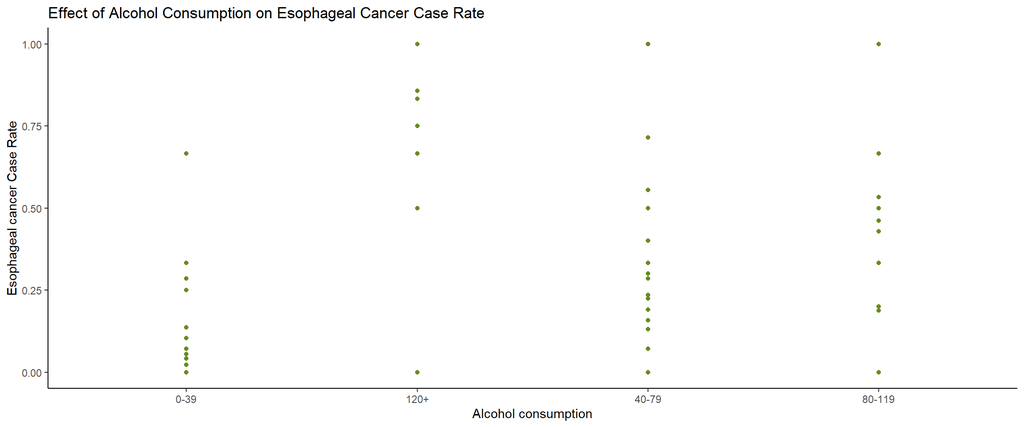

```r
ggplot(esophData, aes(x=alcgp, y=caseRate))+
  geom_point(color="olivedrab4")+
  theme_classic()+
  labs(title="Effect of Alcohol Consumption on Esophageal Cancer Case Rate",
            y="Esophageal cancer Case Rate",
            x="Alcohol consumption")
```

Tobacco consumption also seem to effect cancer case rate especialy above 30g daily consumption cancer risk is incrases.

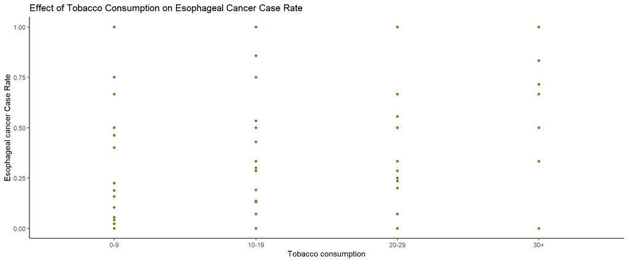

```r
ggplot(esophData, aes(x=tobgp, y=caseRate))+
  geom_point(color="olivedrab4")+
  theme_classic()+
  labs(title="Effect of Tobacco Consumption on Esophageal Cancer Case Rate",
            y="Esophageal cancer Case Rate",
            x="Tobacco consumption")
```

Between 25-44 ages esophageal cancer rate seems to be lower, after 44+ age cancer risk increases.

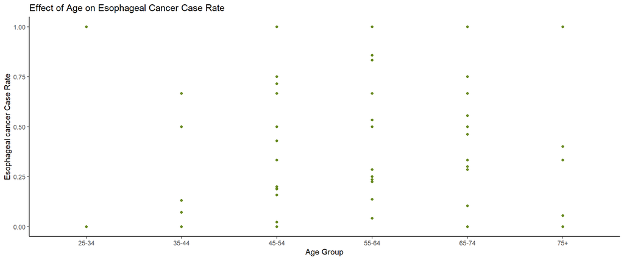

```r
ggplot(esophData, aes(x=agegp, y=caseRate))+
  geom_point(color="olivedrab4")+
  theme_classic()+
  labs(title="Effect of Age on Esophageal Cancer Case Rate",
            y="Esophageal cancer Case Rate",
            x="Age Group")
```

### Linear Regression

Linear Regression model is constructed to see whether age, tobacco consumption and alcohol consumption effects the risk of having esophageal cancer.

```r
esophModel<-lm(caseRate~as.factor(agegp)+alcgp+tobgp, esophData)
summary(esophModel)
```

```
##
## Call:
## lm(formula = caseRate ~ as.factor(agegp) + alcgp + tobgp, data = esophData)
##
## Residuals:
##      Min       1Q   Median       3Q      Max
## -0.49693 -0.11574  0.01092  0.11378  0.64318
##
## Coefficients:
##                    Estimate Std. Error t value Pr(>|t|)
## (Intercept)         0.06928    0.06114   1.133   0.2607
## as.factor(agegp).L  0.49312    0.06158   8.008 1.06e-11 ***
## as.factor(agegp).Q -0.06508    0.06079  -1.071   0.2877
## as.factor(agegp).C -0.02234    0.05912  -0.378   0.7066
## as.factor(agegp)^4  0.09765    0.05776   1.691   0.0950 .
## as.factor(agegp)^5 -0.02576    0.05631  -0.457   0.6486
## alcgp120+           0.55190    0.06766   8.157 5.51e-12 ***
## alcgp40-79          0.14682    0.06608   2.222   0.0293 *
## alcgp80-119         0.28596    0.06759   4.231 6.43e-05 ***
## tobgp10-19          0.03743    0.06450   0.580   0.5634
## tobgp20-29          0.01313    0.06836   0.192   0.8482
## tobgp30+            0.16147    0.06799   2.375   0.0201 *
## ---
## Signif. codes:  0 '***' 0.001 '**' 0.01 '*' 0.05 '.' 0.1 ' ' 1
##
## Residual standard error: 0.2234 on 76 degrees of freedom
## Multiple R-squared:  0.6585, Adjusted R-squared:  0.6091
## F-statistic: 13.32 on 11 and 76 DF,  p-value: 1.01e-13
```

## Young People Survey

In the second part of the assignment, Young People Survey data will be analyzed deeply in order to get insights from it.

Data is downloaded from [Kaggle](https://www.kaggle.com/miroslavsabo/young-people-survey)

### Import data

There are 150 columns (interests & hobbies categories) and 1010 rows(responses) in the data.

```r
surveyData<- read.csv("responses.csv",header=TRUE)
surveyData %>% glimpse()
```

```
## Rows: 1,010
## Columns: 150
## $ Music                          <int> 5, 4, 5, 5, 5, 5, 5, 5, 5, 5, 5, 5, ...
## $ Slow.songs.or.fast.songs       <int> 3, 4, 5, 3, 3, 3, 5, 3, 3, 3, 3, 3, ...
## $ Dance                          <int> 2, 2, 2, 2, 4, 2, 5, 3, 3, 2, 3, 1, ...
## $ Folk                           <int> 1, 1, 2, 1, 3, 3, 3, 2, 1, 5, 2, 1, ...
## $ Country                        <int> 2, 1, 3, 1, 2, 2, 1, 1, 1, 2, 1, 1, ...
## $ Classical.music                <int> 2, 1, 4, 1, 4, 3, 2, 2, 2, 2, 2, 4, ...
## $ Musical                        <int> 1, 2, 5, 1, 3, 3, 2, 2, 4, 5, 3, 1, ...
## $ Pop                            <int> 5, 3, 3, 2, 5, 2, 5, 4, 3, 3, 4, 2, ...
## $ Rock                           <int> 5, 5, 5, 2, 3, 5, 3, 5, 5, 5, 3, 5, ...
## $ Metal.or.Hardrock              <int> 1, 4, 3, 1, 1, 5, 1, 1, 5, 2, 2, 1, ...
## $ Punk                           <int> 1, 4, 4, 4, 2, 3, 1, 2, 1, 3, 1, 1, ...
## $ Hiphop..Rap                    <int> 1, 1, 1, 2, 5, 4, 3, 3, 1, 2, 3, 1, ...
## $ Reggae..Ska                    <int> 1, 3, 4, 2, 3, 3, 1, 2, 2, 4, 2, 1, ...
```

[output cut: 137 more lines]

139 out of 150 columns are numeric.

```r
surveyDataNumeric<-select_if(surveyData, is.numeric) %>%
                  replace(is.na(.), 0)
```

People taken this survey is 20 years old on average.

```r
mean(surveyDataNumeric$Age)
```

```
## [1] 20.29208
```

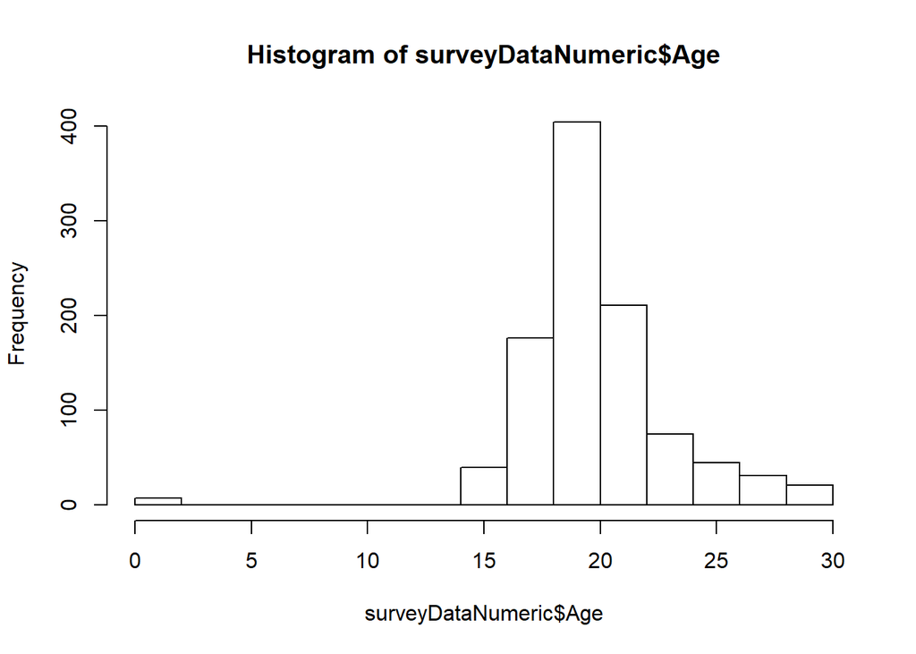

```r
hist(surveyDataNumeric$Age)
```

#### PCA Analysis

About %80 percent of population is explained by 70 variables so if a prediction model is wanted to be constructed, not all the variables are needed to be included into the model. One of two variables that have strong correlation between can be excluded from the model.

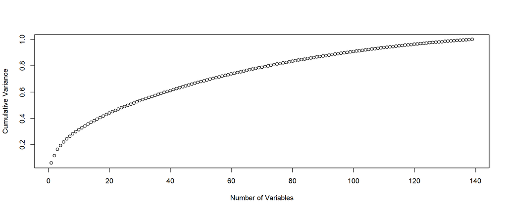

```r
survey_pca <- princomp(surveyDataNumeric,cor=T)

plot(cumsum(survey_pca$sdev^2 / sum(survey_pca$sdev^2)), type="b",
     xlab="Number of Variables",
     ylab="Cumulative Variance")
```

### Clustering

#### All Hobbies & Interests

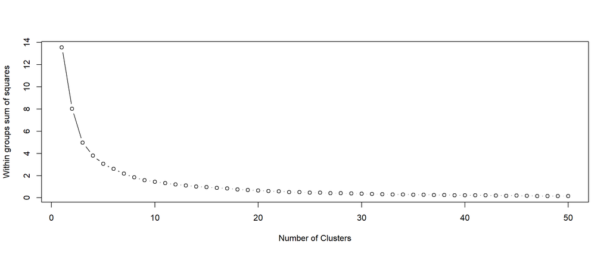

```r
sdNumAll_dist <- 1 - cor(surveyDataNumeric)
sdNumAll_dist_sc <- cmdscale(sdNumAll_dist,k=2)
colnames(sdNumAll_dist_sc) <- c("x","y")

set.seed(58)

#Find optimal number of clusters

  #Initialize total within sum of squares , wss
  wss<-0

  #For 1 to 50 cluster centers apply k-means
  for(i in 1:50){
    kmSurvey<-kmeans(sdNumAll_dist_sc, centers = i, nstart = 20)
    wss[i]<-kmSurvey$tot.withinss}

  #Plot total within sum of squares vs. number of squares
  plot(1:50,wss,type="b",
       xlab = "Number of Clusters",
       ylab = "Within groups sum of squares")
```

Then, K-means algorithm was applied to whole numeric variables with 6 centers. Which hobbies & interests is in which cluster and plot of clusters can be seen below.

```r
set.seed(58)
#Apply K-Means with 6 clusters
sclustAll<-kmeans(sdNumAll_dist_sc,centers=6)

##Get the clusters
d_sclustAll<-data.frame(hobbies_interests =names(sclustAll$cluster),cluster=sclustAll$cluster) %>%
            arrange(cluster,hobbies_interests)

d_sclustAll %>%
  kbl() %>%
  kable_minimal(full_width = F)
```

|  | hobbies_interests | cluster |
| --- | --- | --- |
| Alternative | Alternative | 1 |
| Art.exhibitions | Art.exhibitions | 1 |
| Biology | Biology | 1 |
| Chemistry | Chemistry | 1 |
| Classical.music | Classical.music | 1 |
| Country | Country | 1 |
| Countryside..outdoors | Countryside..outdoors | 1 |
| Elections | Elections | 1 |
| Finances | Finances | 1 |
| Folk | Folk | 1 |
| Medicine | Medicine | 1 |
| Musical.instruments | Musical.instruments | 1 |
| Opera | Opera | 1 |
| Psychology | Psychology | 1 |
| Reading | Reading | 1 |
| Religion | Religion | 1 |
| Rock.n.roll | Rock.n.roll | 1 |
| Self.criticism | Self.criticism | 1 |
| Swing..Jazz | Swing..Jazz | 1 |
| Theatre | Theatre | 1 |
| Thinking.ahead | Thinking.ahead | 1 |
| Workaholism | Workaholism | 1 |
| Writing | Writing | 1 |
| Ageing | Ageing | 2 |
| Appearence.and.gestures | Appearence.and.gestures | 2 |
| Celebrities | Celebrities | 2 |
| Dancing | Dancing | 2 |
| Dangerous.dogs | Dangerous.dogs | 2 |
| Darkness | Darkness | 2 |
| Getting.angry | Getting.angry | 2 |

[output cut: 109 more lines]

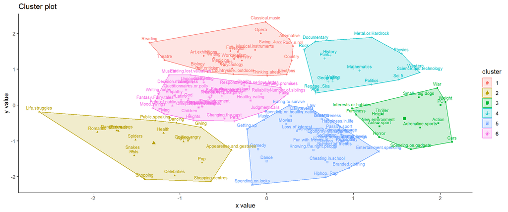

```r
fviz_cluster(sclustAll, data = sdNumAll_dist_sc, pointsize = 1,
             labelsize = 8,  ggtheme = theme_classic())
```

To further explore data and get insights, some of the hobbies & interests are grouped together and analyses are made accordingly.

#### Music

K-means algorithm is applied to music genres and clusters of music genres can be seen on the plot below.

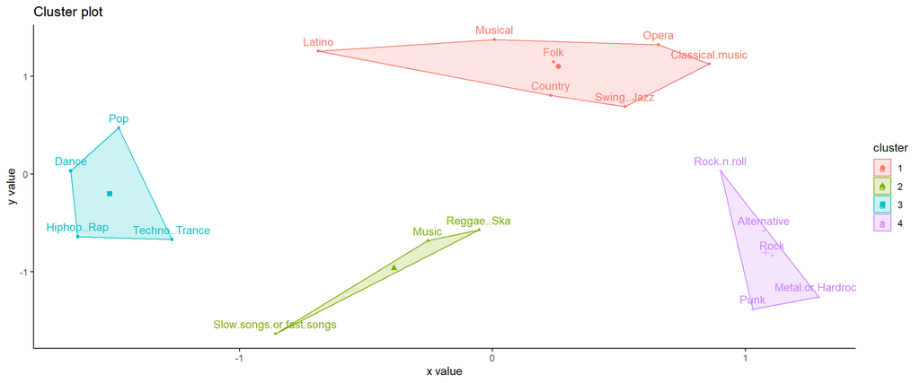

```r
surveyDataMusic<-surveyDataNumeric %>%
                 select(Music:Opera)

sdNumM_dist <- 1 - cor(surveyDataMusic)
sdNumM_dist_sc <- cmdscale(sdNumM_dist,k=2)
colnames(sdNumM_dist_sc) <- c("x","y")

set.seed(58)
#Apply K-Means
sclustM<-kmeans(sdNumM_dist_sc,centers=4)

#Plot clusters
fviz_cluster(sclustM, data = sdNumM_dist_sc, pointsize = 1,
             labelsize = 11,  ggtheme = theme_classic())
```

Also, hierarchical tree for music genres can be seen on below dendogram.

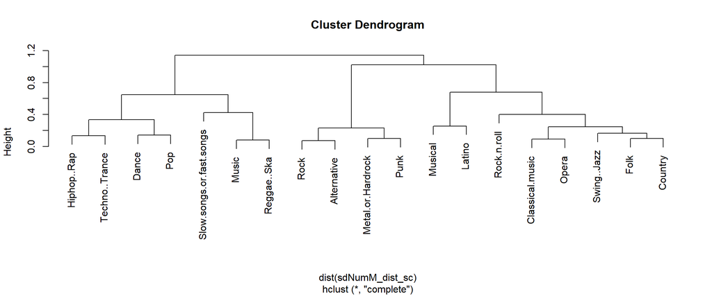

```r
hclustMusic<-hclust(d=dist(sdNumM_dist_sc), method = "complete")
plot(hclustMusic)
```

#### Movies

Same analysis is made to movies as well. Clusters of film genres can be seen on the plot below.

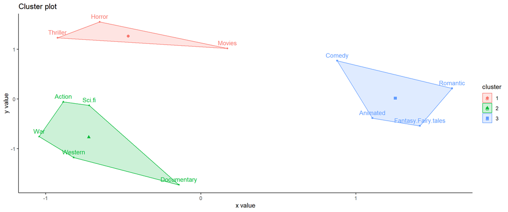

```r
surveyDataMovies<-surveyDataNumeric %>%
                 select(Movies:Action)

sdNumMov_dist <- 1 - cor(surveyDataMovies)
sdNumMov_dist_sc <- cmdscale(sdNumMov_dist,k=2)
colnames(sdNumMov_dist_sc) <- c("x","y")

set.seed(58)
#Apply K-Means
sclustMov<-kmeans(sdNumMov_dist_sc,centers=3)

#Plot clusters
fviz_cluster(sclustMov, data = sdNumMov_dist_sc, pointsize = 1,
             labelsize = 11,  ggtheme = theme_classic())
```

Hierarchical tree for film genres can be seen on below dendogram

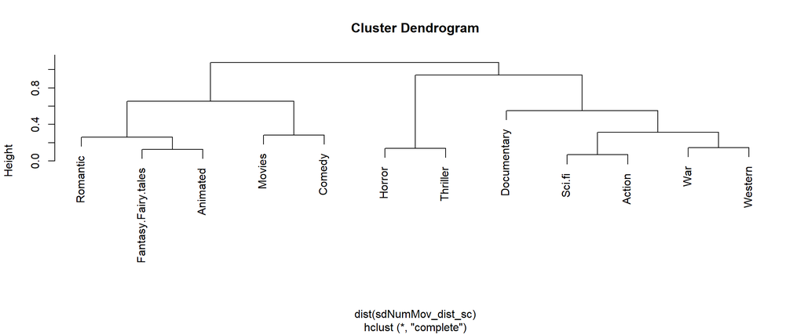

```r
hclustMovie<-hclust(d=dist(sdNumMov_dist_sc), method = "complete")
plot(hclustMovie)
```

#### Humanities and Science

Clusters of Humanities and Science disciplines:

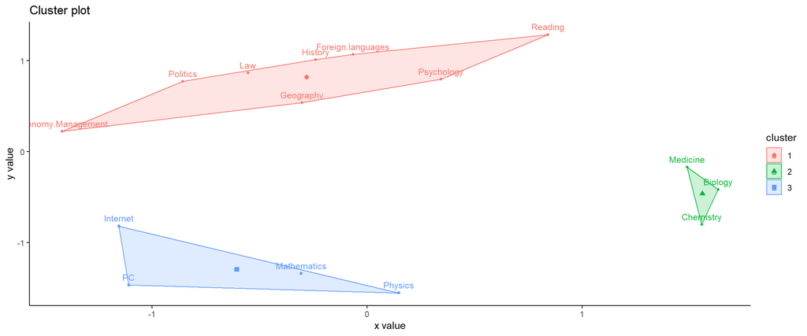

```r
surveyDataHS<-surveyDataNumeric %>%
                 select(History:Law)

sdNumHS_dist <- 1 - cor(surveyDataHS)
sdNumHS_dist_sc <- cmdscale(sdNumHS_dist,k=2)
colnames(sdNumHS_dist_sc) <- c("x","y")

set.seed(58)
#Apply K-Means
sclustHS<-kmeans(sdNumHS_dist_sc,centers=3)

#Plot clusters
fviz_cluster(sclustHS, data = sdNumHS_dist_sc, pointsize = 1,
             labelsize = 10,  ggtheme = theme_classic())
```

Hierarchical tree for Humanities and Science disciplines:

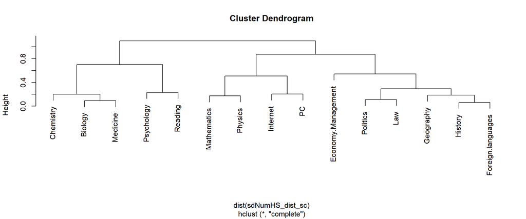

```r
hclustHS<-hclust(d=dist(sdNumHS_dist_sc), method = "complete")
plot(hclustHS)
```

#### Behavior and Personality Traits

Clusters of Behavior and Personality traits:

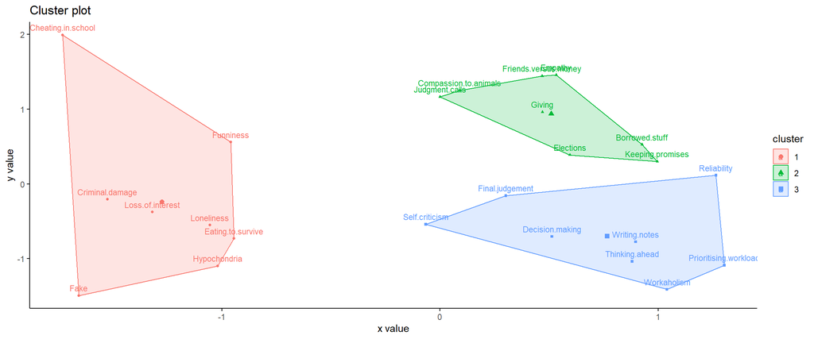

```r
surveyDataBP<-surveyDataNumeric %>%
                 select(Prioritising.workload:Cheating.in.school)

sdNumBP_dist <- 1 - cor(surveyDataBP)
sdNumBP_dist_sc <- cmdscale(sdNumBP_dist,k=2)
colnames(sdNumBP_dist_sc) <- c("x","y")

set.seed(58)
#Apply K-Means
sclustBP<-kmeans(sdNumBP_dist_sc,centers=3)

#Plot clusters
fviz_cluster(sclustBP, data = sdNumBP_dist_sc, pointsize = 1,
             labelsize = 9,  ggtheme = theme_classic())
```

Hierarchical tree for Behavior and Personality traits:

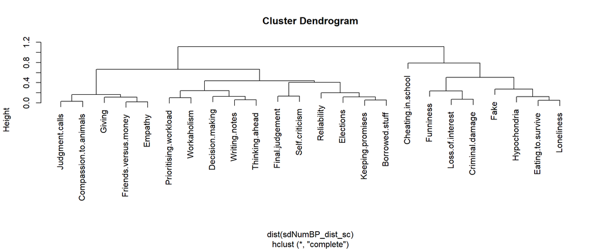

```r
hclustBP<-hclust(d=dist(sdNumBP_dist_sc), method = "complete")
plot(hclustBP)
```

#### Fears

Clusters of fears:

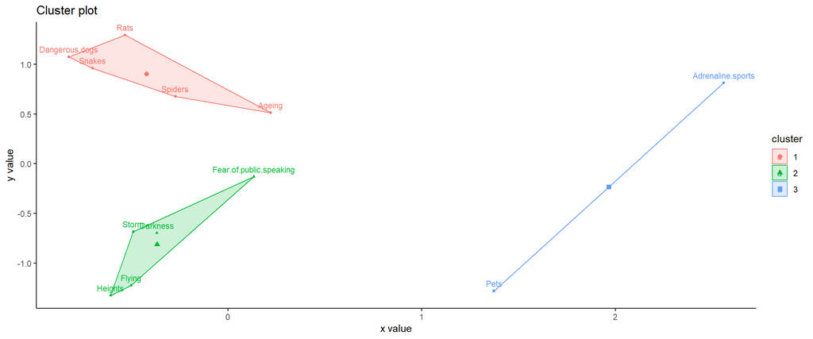

```r
surveyDataF<-surveyDataNumeric %>%
                 select(Adrenaline.sports:Fear.of.public.speaking)

sdNumF_dist <- 1 - cor(surveyDataF)
sdNumF_dist_sc <- cmdscale(sdNumF_dist,k=2)
colnames(sdNumF_dist_sc) <- c("x","y")

set.seed(58)
#Apply K-Means
sclustF<-kmeans(sdNumF_dist_sc,centers=3)

#Plot clusters
fviz_cluster(sclustF, data = sdNumF_dist_sc, pointsize = 1,
             labelsize = 9,  ggtheme = theme_classic())
```

Hierarchical tree for fears:

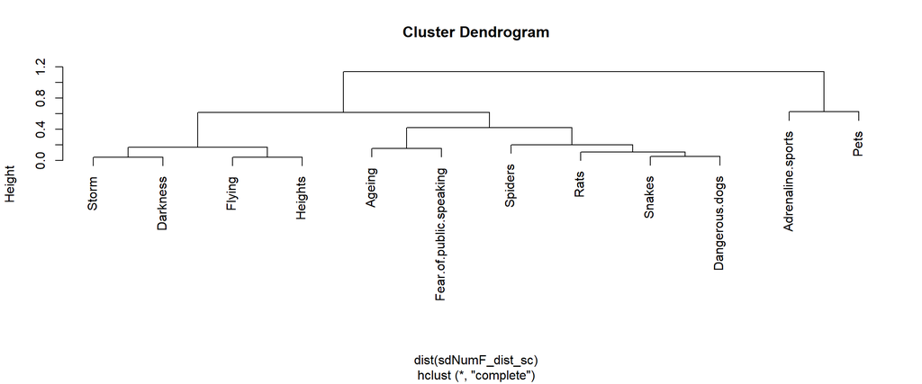

```r
hclustF<-hclust(d=dist(sdNumF_dist_sc), method = "complete")
plot(hclustF)
```

#### Regression on Happiness

```r
myFunc <-paste("Happiness.in.life ~ Music",paste("+", names(surveyData)[-1],collapse="",sep=""))
Happiness<-lm(myFunc,data = surveyData)
summary(Happiness)
```

```
##
## Call:
## lm(formula = myFunc, data = surveyData)
##
## Residuals:
##      Min       1Q   Median       3Q      Max
## -1.76119 -0.35338  0.02573  0.36781  1.78344
##
## Coefficients:
##                                             Estimate Std. Error t value
## (Intercept)                               -1.3284031  2.1728104  -0.611
## Music                                      0.0486570  0.0505923   0.962
## Slow.songs.or.fast.songs                   0.0014154  0.0366524   0.039
## Dance                                      0.0178738  0.0312746   0.572
## Folk                                       0.0270057  0.0308563   0.875
## Country                                    0.0281011  0.0309929   0.907
## Classical.music                            0.0705337  0.0328178   2.149
## Musical                                   -0.0140153  0.0286906  -0.488
## Pop                                        0.0439474  0.0304330   1.444
## Rock                                       0.0032462  0.0344509   0.094
## Metal.or.Hardrock                         -0.0306712  0.0282115  -1.087
## Punk                                       0.0170873  0.0291949   0.585
## Hiphop..Rap                               -0.0095745  0.0265037  -0.361
## Reggae..Ska                                0.0635256  0.0276885   2.294
## Swing..Jazz                               -0.0066994  0.0291763  -0.230
## Rock.n.roll                               -0.0432297  0.0311477  -1.388
## Alternative                               -0.0345605  0.0264186  -1.308
## Latino                                     0.0142309  0.0277919   0.512
## Techno..Trance                            -0.0355154  0.0245010  -1.450
## Opera                                     -0.0167686  0.0325004  -0.516
## Movies                                    -0.0055804  0.0502142  -0.111
## Horror                                    -0.0158669  0.0250659  -0.633
## Thriller                                   0.0081169  0.0304060   0.267
## Comedy                                     0.0147525  0.0442661   0.333
## Romantic                                  -0.0184459  0.0308340  -0.598
## Sci.fi                                    -0.0157844  0.0264479  -0.597
## War                                       -0.0118328  0.0253709  -0.466
## Fantasy.Fairy.tales                        0.0167369  0.0368592   0.454
## Animated                                   0.0082213  0.0342447   0.240
## Documentary                               -0.0336244  0.0307222  -1.094
```

[output cut: 301 more lines]

```
## Educationprimary school                     0.0923 .
## Educationsecondary school                   0.4841
## Only.childno                                0.6674
## Only.childyes                               0.8096
## Village...towncity                          0.2963
## Village...townvillage                       0.3322
## House...block.of.flatsblock of flats        0.4909
## House...block.of.flatshouse/bungalow        0.4883
## ---
## Signif. codes:  0 '***' 0.001 '**' 0.01 '*' 0.05 '.' 0.1 ' ' 1
##
## Residual standard error: 0.6294 on 517 degrees of freedom
##   (324 observations deleted due to missingness)
## Multiple R-squared:  0.5576, Adjusted R-squared:  0.4138
## F-statistic: 3.879 on 168 and 517 DF,  p-value: < 2.2e-16
```

## References

- https://stackoverflow.com/questions/7069076/split-column-at-delimiter-in-data-frame
- https://stackoverflow.com/questions/5863097/selecting-only-numeric-columns-from-a-data-frame
- https://learn.datacamp.com/courses/unsupervised-learning-in-r